# LinkedIn Article

```r
library(cansim)
library(cancensus)
library(purrr)
library(dplyr)
```

```r
library(ggplot2)
```

## Get more done with Canadian public data

Statistics Canada releases some of the best and most detailed public data of any statistical agency in the world, but while the data is available it is not always easy or efficient to work with. Finding, assembling, and manipulating this data often requires retrieving from multiple locations and multiple file types. This process is inefficient, does not scale, and reduces reproducibility.

cansim and cancensus are a pair of R packages created by Jens von Bergmann and myself that are designed to address these challenges and to make it much easier to work with Statistics Canada’s Census and socioeconomic datasets. These packages are used by government agencies, academics, data journalists, and professionals in the private sector.

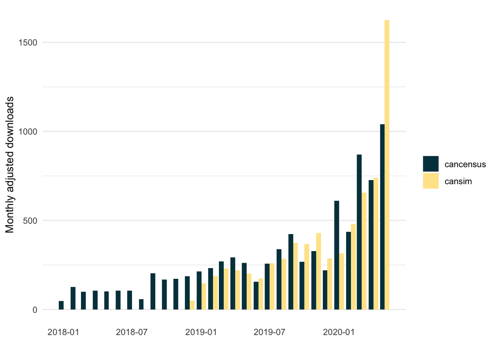

```r
library(adjustedcranlogs)
comps <- adj_cran_downloads(c('cancensus','cansim'),
                            from = "2018-01-01",
                            to = "2020-05-31")

comps %>%
  mutate(ym = lubridate::floor_date(date, "month")) %>%
  group_by(ym, package) %>%
  summarise(adjusted_downloads = sum(adjusted_downloads, na.rm = TRUE)) %>%
  ggplot(., aes(x = ym, y = adjusted_downloads,
                fill = package,
                group = package)) +
  geom_bar(stat = "identity", position = "dodge") +
  labs(x = "", y = "Monthly adjusted downloads", colour = "", fill = "") +
  theme_minimal() +
  theme(panel.grid.major.x = element_blank(),
        panel.grid.minor.x = element_blank()) +
  scico::scale_fill_scico_d(palette = "bamako")
```

## Cancensus

### Installation and configuration

Cancensus is on CRAN and installation is easy.

```r
install.packages("cancensus")
library(cancensus)
```

Statistics Canada does not provide API access to Census data. [CensusMapper](https://censusmapper.ca/) which is run by the coauthor of the cancensus package clones all publicly available Census data into its own data lake to provide an API mirror. To use the API through the R package you will need to supply an API key, which are freely available from CensusMapper. To check your API key once signed up, just go to “Edit Profile” (in the top-right of the CensusMapper menu bar). The Cancensus package also enables local caching of data to speed up working with datasets. You can store your key securely as well as specify a location to store cached data by adding:

```
options(cancensus.api_key = "your_api_key")
options(cancensus.cache_path = 'XXX')
```

This can be made permanent across sessions by adding this code to your `.rprofile` file.

### Quick demo

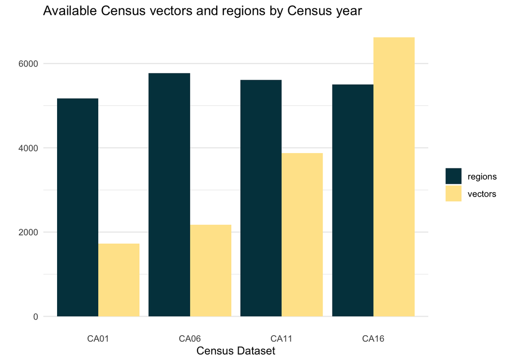

Cancensus has complete data and geography for the 2001, 2006, 2011 (NHS), and 2016 Census years, as well as additional Census-related datasets made available through contributions to open-data. As future Census datasets and other related datasets become available, they will be added for use. To view all available datasets at this time:

```r
list_census_datasets()
```

```
## Querying CensusMapper API for available datasets...
```

```
## # A tibble: 26 x 2
##    dataset description
##    <chr>   <chr>
##  1 CA01    2001 Canada Census
##  2 CA06    2006 Canada Census
##  3 CA11    2011 Canada Census and NHS
##  4 CA16    2016 Canada Census
##  5 CA01xSD 2001 Canada Census xtab - Structural type by Document type, via CMHC
##  6 CA06xSD 2006 Canada Census xtab - Structural type by Document type, via CMHC
##  7 CA11xSD 2011 Canada Census xtab - Structural type by Document type, via CMHC
##  8 CA16xSD 2016 Canada Census xtab - Structural type by Document type, via CMHC
##  9 TX2000  2000 Taxfiler data, via CMHC
## 10 TX2001  2001 Taxfiler data, via CMHC
## # … with 16 more rows
```

and to view available Census data vectors regions:

```r
list_census_regions("CA16")
```

```
## Reading regions list from local cache.
```

```
## # A tibble: 5,504 x 8
##    region name              level     pop municipal_status CMA_UID CD_UID PR_UID
##    <chr>  <chr>             <chr>   <int> <chr>            <chr>   <chr>  <chr>
##  1 01     Canada            C      3.52e7 <NA>             <NA>    <NA>   <NA>
##  2 35     Ontario           PR     1.34e7 <NA>             <NA>    <NA>   <NA>
##  3 24     Quebec            PR     8.16e6 <NA>             <NA>    <NA>   <NA>
##  4 59     British Columbia  PR     4.65e6 <NA>             <NA>    <NA>   <NA>
##  5 48     Alberta           PR     4.07e6 <NA>             <NA>    <NA>   <NA>
##  6 46     Manitoba          PR     1.28e6 <NA>             <NA>    <NA>   <NA>
##  7 47     Saskatchewan      PR     1.10e6 <NA>             <NA>    <NA>   <NA>
##  8 12     Nova Scotia       PR     9.24e5 <NA>             <NA>    <NA>   <NA>
##  9 13     New Brunswick     PR     7.47e5 <NA>             <NA>    <NA>   <NA>
## 10 10     Newfoundland and… PR     5.20e5 <NA>             <NA>    <NA>   <NA>
## # … with 5,494 more rows
```

```r
list_census_vectors("CA16")
```

```
## # A tibble: 6,623 x 7
##    vector  type   label       units parent_vector aggregation  details
##    <chr>   <fct>  <chr>       <fct> <chr>         <chr>        <chr>
##  1 v_CA16… Total  Population… Numb… <NA>          Additive     CA 2016 Census; …
##  2 v_CA16… Total  Population… Numb… <NA>          Additive     CA 2016 Census; …
##  3 v_CA16… Total  Population… Numb… <NA>          Average of … CA 2016 Census; …
##  4 v_CA16… Total  Total priv… Numb… <NA>          Additive     CA 2016 Census; …
##  5 v_CA16… Total  Private dw… Numb… v_CA16_404    Additive     CA 2016 Census; …
##  6 v_CA16… Total  Population… Ratio <NA>          Average of … CA 2016 Census; …
##  7 v_CA16… Total  Land area … Numb… <NA>          Additive     CA 2016 Census; …
##  8 v_CA16… Total  Total - Age Numb… <NA>          Additive     CA 2016 Census; …
##  9 v_CA16… Male   Total - Age Numb… <NA>          Additive     CA 2016 Census; …
## 10 v_CA16… Female Total - Age Numb… <NA>          Additive     CA 2016 Census; …
## # … with 6,613 more rows
```

Detailed tutorials, reference material, and vignettes are available on the Cancensus package website at https://mountainmath.github.io/cancensus/index.html. To leave feedback, issues, feature requests, or to download the latest development version, checkout, star, and fork the package at https://github.com/mountainMath/cancensus/.

The main advantages of using cancensus are efficiency of code, scalability of analysis, and complete reproducibility. Here’s a few quick demos showing how much you can accomplish with very little code.

#### Ex. 1 - Downloading and comparing median household income across top 10 CMAs by population

```r
library(dplyr)
library(ggplot2)

# Find vector for median household income
search_census_vectors("median total income of households","CA16", type = "Total")
```

```
## # A tibble: 1 x 7
##   vector  type  label        units parent_vector aggregation  details
##   <chr>   <fct> <chr>        <fct> <chr>         <chr>        <chr>
## 1 v_CA16… Total Median tota… Curr… v_CA16_2396   Median of v… CA 2016 Census; 1…
```

```r
# Returns "v_CA16_2397"

# Select top-10 CMAs by populations
top10cmas <- list_census_regions("CA16") %>%
  filter(level == "CMA") %>%
  top_n(10, pop) %>%
  as_census_region_list()
```

```
## Reading regions list from local cache.
```

```
## Reading vectors data from local cache.
```

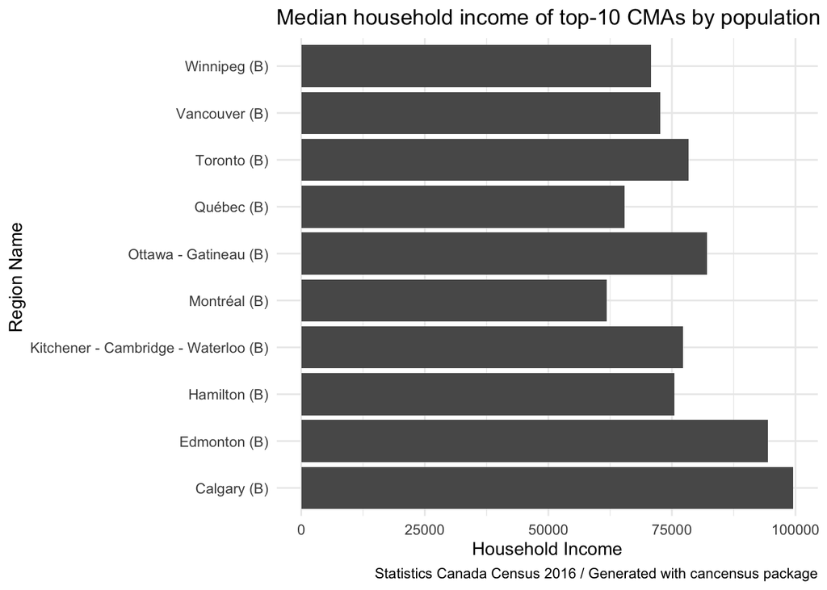

```r
# Retrieve data
get_census("CA16", regions = top10cmas, vectors = c("v_CA16_2397")) %>%
  select(`Region Name`, `Household Income` = `v_CA16_2397: Median total income of households in 2015 ($)`) %>%
  ggplot(., aes(x = `Region Name`, y = `Household Income`)) +
  geom_bar(stat = "identity") +
  theme_minimal() +
  coord_flip()  +
  labs(title = "Median household income of top-10 CMAs by population",
       caption="Statistics Canada Census 2016 / Generated with cancensus package")
```

#### Ex. 2 - Visualizing distribution of people of Ukrainian-heritage across Canada

First, search across vectors to find the right vector.

```r
search_census_vectors("Ukrainian","CA16", type = "Total") %>%
  select(vector, details)
```

```
## # A tibble: 5 x 2
##   vector      details
##   <chr>       <chr>
## 1 v_CA16_1022 CA 2016 Census; 100% data; Language; Total - Mother tongue for th…
## 2 v_CA16_1829 CA 2016 Census; 100% data; Language; Total - Language spoken most…
## 3 v_CA16_3072 CA 2016 Census; 25% Data; Total - Knowledge of languages for the …
## 4 v_CA16_4185 CA 2016 Census; 25% Data; Minority / Origin; Total - Ethnic origi…
## 5 v_CA16_6326 CA 2016 Census; 25% Data; Work; Total - Language used most often …
```

```r
library(sf)
prairies <- list_census_regions('CA16') %>% filter(name %in% c("Alberta","Saskatchewan","Manitoba")) %>% as_census_region_list()
```

```
## Reading regions list from local cache.
```

```r
ukrainian_prairie <- get_census(dataset = "CA16", region = prairies, level = "CT", vectors = c("v_CA16_4185"), geo_format = "sf")
```

```
## Reading vectors data from local cache.
```

```
## Reading geo data from local cache.
```

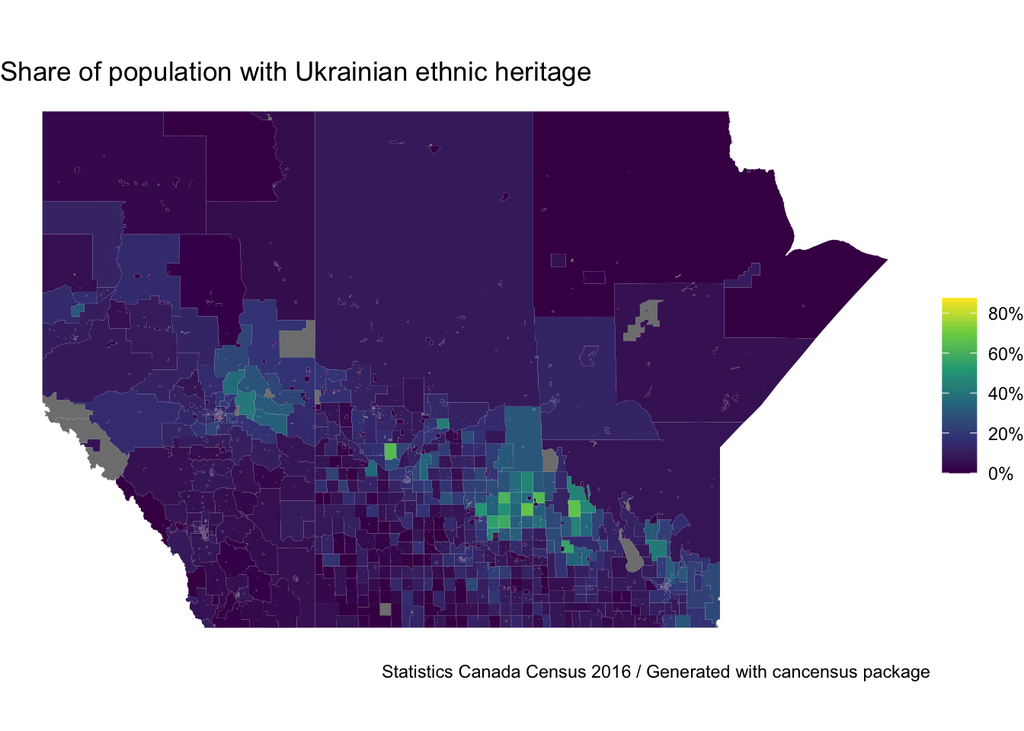

```r
# Calculate share of population with Ukrainian heritage
ukrainian_prairie %>%
  mutate(ukrainian_share = `v_CA16_4185: Ukrainian`/Population) %>%
  ggplot(.) +
  geom_sf(aes(fill = ukrainian_share), colour = NA) +
  scale_fill_viridis_c(labels=scales::percent) +
  theme_void() +
  labs(title = "Share of population with Ukrainian ethnic heritage",
       fill = "",
       caption="Statistics Canada Census 2016 / Generated with cancensus package")
```

#### Ex.3 - Visualizing child poverty rates in the city of Toronto Census subdivision

Statistics Canada’s region code for this geography is 3520005 and the vector code v_CA16_2573 has data for the prevalence of low income residents between ages 0 and 17.

```
## Reading vectors data from local cache.
```

```
## Reading geo data from local cache.
```

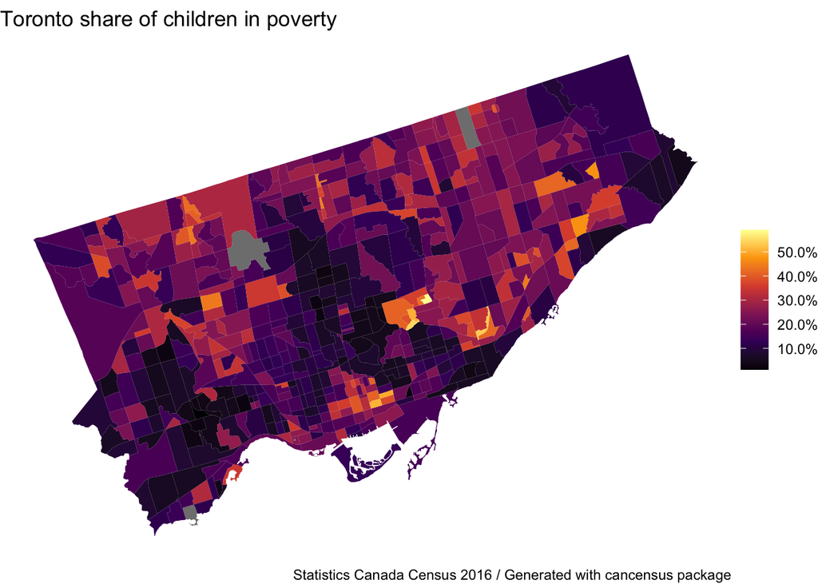

```r
get_census("CA16",regions=list(CSD="3520005"),vectors=c(lico_at="v_CA16_2573"),
                           geo_format="sf",level="CT") %>%
  ggplot(.) +
  geom_sf(aes(fill=lico_at/100), colour = NA) +
  scale_fill_viridis_c(option = "inferno",labels=scales::percent) +
  theme_void() +
  labs(title="Toronto share of children in poverty",fill=NULL,caption="Statistics Canada Census 2016 / Generated with cancensus package")
```

### Reproducible examples with code

There many additional features in the package to make it easier to work with Census variables, including tools for managing variable hierarchy trees. As Census data is by definition spatial data, a standardized and simple to work with spatial output allows for easy combinations with non-Census datasets. Below is a list of fully reproducible examples that show more complex package usage or integrations with other datasets.

- [Mixing Covid-19 and Census data](https://doodles.mountainmath.ca/blog/2020/05/27/on-mixing-covid-19-and-census-data/)
- [Using Census data to measure ethnic diversity and segregation across Canadian cities](https://www.dshkol.com/2018/diversity-and-segregation-canadian-cities/)
- [Understanding income distributions across geographies and time](https://doodles.mountainmath.ca/blog/2018/10/28/understanding-income-distributions-across-geographies-and-time/)
- [t-SNE visualizations for finding city lookalikes in Census data](https://www.dshkol.com/2018/mirror-images-clustering-cities-demographics/)

## Cansim

### Installation and getting started

The cansim package is available on CRAN and is easy to download.

```r
install.packages("cansim")
```

Many of the data tables available in Statistics Canada’s data repository are quite large in size. After downloading tables, the cansim package will cache data in a temporary directory for the duration of the current R session. This reduces unnecessary waiting when recompiling code. To force a refresh of the data, pass the refresh=TRUE option in the function call. You can specify the location of the cache in your .Rprofile file.

```r
options(cansim.cache_path="your cache path")
```

If you know the data table catalogue number you are interested in, use get_cansim to download the entire table.

```r
data <- get_cansim("14-10-0293")
```

```
## Accessing CANSIM NDM product 14-10-0293 from Statistics Canada
```

```
## Parsing data
```

```
## Folding in metadata
```

By default, the data tables retrieved by the package comes in the original format provided by Statistics Canada, but often it is convenient to cast the data into a cleaner data object and to use the included data to transform values by their appropriate scaling or unit variable. This makes it easier to work on the data directly and minimize unnecessary data manipulation. For example, data may be reported as a value in “millions” but with unitless numbers. A built-in convenience function, normalize_cansim_values, refers to the appropriate scaling unit and transforms the raw values into the appropriate absolute value.

```r
data <- get_cansim("14-10-0293") %>%
  normalize_cansim_values
```

```
## Reading CANSIM NDM product 14-10-0293 from cache.
```

```r
head(data)
```

```
## # A tibble: 6 x 20
##   REF_DATE GEO   DGUID `Labour force c… Statistics UOM   UOM_ID VECTOR
##   <chr>    <chr> <chr> <chr>            <chr>      <chr> <chr>  <chr>
## 1 2001-03  Cana… 2016… Population       Estimate   Pers… 249    v9141…
## 2 2001-03  Cana… 2016… Labour force     Estimate   Pers… 249    v9141…
## 3 2001-03  Cana… 2016… Labour force     Standard … Pers… 249    v1018…
## 4 2001-03  Cana… 2016… Labour force     Standard … Pers… 249    v1018…
## 5 2001-03  Cana… 2016… Employment       Estimate   Pers… 249    v9141…
## 6 2001-03  Cana… 2016… Employment       Standard … Pers… 249    v1018…
## # … with 12 more variables: COORDINATE <chr>, VALUE <dbl>, STATUS <chr>,
## #   SYMBOL <chr>, TERMINATED <chr>, DECIMALS <chr>, GeoUID <chr>,
## #   `Classification Code for Labour force characteristics` <chr>, `Hierarchy
## #   for Labour force characteristics` <chr>, `Classification Code for
## #   Statistics` <chr>, `Hierarchy for Statistics` <chr>, Date <date>
```

Taking a look at an overview of the data within a table is a common first step. This is implemented in the package with the get_cansim_table_overview(table_number) function.

```r
get_cansim_table_overview("14-10-0293")
```

```
## Labour force characteristics by economic region, three-month moving average, unadjusted for seasonality, last 5 months
## CANSIM Table 14-10-0293
## Start Reference Period: 2001-03-01, End Reference Period: 2020-04-01, Frequency: Monthly
##
## Column Geography (76)
## Canada, Newfoundland and Labrador, Avalon Peninsula, Newfoundland and Labrador, South Coast-Burin Peninsula and Notre Dame-Central Bonavista Bay, Newfoundland and Labrador, West Coast-Northern Peninsula-Labrador, Newfoundland and Labrador, Prince Edward Island, Nova Scotia, Cape Breton, Nova Scot…
##
## Column Labour force characteristics (10)
## Population, Labour force, Employment, Full-time employment, Part-time employment, Unemployment, Not in labour force, Unemployment rate, Participation rate, Employment rate
##
## Column Statistics (3)
## Estimate, Standard error of estimate, Standard error of year-over-year change
```

When a table number is unknown, you can browse the available tables or search by survey name, keyword or title.

```r
search_cansim_tables("housing price indexes")
```

```
## Your CANSIM table overview data is 95 days old.
## Consider setting options(cansim.cache_path="your cache path")
## in your .Rprofile and refreshing the table via list_cansim_tables(refresh=TRUE).
```

```
## # A tibble: 11 x 21
##    title title_en title_fr keywords_en keywords keywords_fr notes notes_en
##    <chr> <chr>    <chr>    <chr>       <chr>    <chr>       <chr> <chr>
##  1 New … New hou… Indice … constructi… constru… constructi… <p>N… <p>New …
##  2 Resi… Residen… Indice … housing, h… housing… housing, h… <p>R… <p>Resi…
##  3 Resi… Residen… Indice … housing, h… housing… housing, h… <p>R… <p>Resi…
##  4 Buil… Buildin… Indices… housing, h… housing… housing, h… <p>B… <p>Buil…
##  5 New … New hou… Indice … constructi… constru… constructi… <p>N… <p>New …
##  6 Pric… Price i… Indices… housing, h… housing… housing, h… <p>T… <p>This…
##  7 New … New hou… Indices… constructi… constru… constructi… This… This ta…
##  8 New … New hou… Indices… constructi… constru… constructi… This… This ta…
##  9 Pric… Price i… Indices… housing, h… housing… housing, h… This… This ta…
## 10 Non-… Non-res… Indice … constructi… constru… constructi… <p>A… <p>Arch…
## 11 New … New hou… Indice … constructi… constru… constructi… Mont… Monthly…
## # … with 13 more variables: notes_fr <chr>, state <chr>, subject <chr>,
## #   date_published <chr>, frequency <chr>, revision_id <chr>,
## #   time_period_coverage_start <chr>, time_period_coverage_end <chr>,
## #   metadata_created <chr>, metadata_modified <chr>, url_en <chr>,
## #   url_fr <chr>, cansim_table_number <chr>
```

The cansim package provides many other functions for finding data, working with metadata, and efficiently parsing data structures that make it easier to work with the extensive and varied data available from Statistics Canada.

Additional tutorial vignettes with more details are available on the cansim package website at https://mountainmath.github.io/cansim/index.html. To leave feedback, issues, feature requests, or to download the latest development version, checkout, star, and fork the package at https://github.com/mountainMath/cansim/.

### Reproducible examples with code

#### Ex. 1 - When did new truck sales overtake new car sales in different provinces?

```r
# Searching for Statistics Canada tables about new motor vehicle sales
search_cansim_tables("new motor vehicle sales") %>%
  select(title, keywords, cansim_table_number)
```

```
## Your CANSIM table overview data is 95 days old.
## Consider setting options(cansim.cache_path="your cache path")
## in your .Rprofile and refreshing the table via list_cansim_tables(refresh=TRUE).
```

```
## # A tibble: 2 x 3
##   title                  keywords                              cansim_table_num…
##   <chr>                  <chr>                                 <chr>
## 1 New motor vehicle sal… motor vehicles, retail and wholesale… 20-10-0001
## 2 New motor vehicle sal… motor vehicles, retail and wholesale… 20-10-0002
```

We see that the table we need is “20-10-0001”. We can get more information about that table including table metadata, descriptions of fields, date availability, and other relevant notes by using some of the auxiliary metadata-related functions in the cansim package.

```r
get_cansim_table_info("20-10-0001")
```

```
## Accessing CANSIM NDM product 20-10-0001 from Statistics Canada
```

```
## Parsing data
```

```
## Folding in metadata
```

```
## # A tibble: 1 x 10
##   `Cube Title` `Product Id` `CANSIM Id` URL   `Cube Notes` `Archive Status`
##   <chr>        <chr>        <chr>       <chr> <chr>        <chr>
## 1 New motor v… 20100001     079-0003    http… 1            CURRENT - a cub…
## # … with 4 more variables: Frequency <chr>, `Start Reference Period` <chr>,
## #   `End Reference Period` <chr>, `Total number of dimensions` <chr>
```

```r
get_cansim_table_overview("20-10-0001")
```

```
## New motor vehicle sales
## CANSIM Table 20-10-0001
## Start Reference Period: 1946-01-01, End Reference Period: 2020-02-01, Frequency: Monthly
##
## Column Geography (11)
## Canada, Newfoundland and Labrador, Prince Edward Island, Nova Scotia, New Brunswick, Quebec, Ontario, Manitoba, Saskatchewan, Alberta, ...
##
## Column Vehicle type (3)
## Total, new motor vehicles, Passenger cars, Trucks
##
## Column Origin of manufacture (5)
## Total, country of manufacture, North America, Total, overseas, Japan, Other countries
##
## Column Sales (2)
## Units, Dollars
##
## Column Seasonal adjustment (2)
## Unadjusted, Seasonally adjusted
```

```r
get_cansim_table_notes("20-10-0001")
```

```
## # A tibble: 5 x 4
##   `Dimension name`   `Note ID` `Member Name`        Note
##   <chr>              <chr>     <chr>                <chr>
## 1 <NA>               1         <NA>                 Prior to 1953, data for Can…
## 2 Geography          2         British Columbia an… Includes Yukon, Northwest T…
## 3 Vehicle type       3         Trucks               Trucks include minivans, sp…
## 4 Origin of manufac… 4         Total, overseas      Includes Japan and other co…
## 5 Seasonal adjustme… 5         <NA>                 Seasonally adjusted data fo…
```

Now that we have the table number and see that it includes monthly data going back to the 1940s, let’s download the data. We want to then filter results to include only the relevant categories, limiting our analysis to seasonally unadjusted data for Alberta, Quebec, and Ontario, and specifying a starting date of January 1980.

```r
mv_sales <- get_cansim("20-10-0001")
```

```
## Reading CANSIM NDM product 20-10-0001 from cache.
```

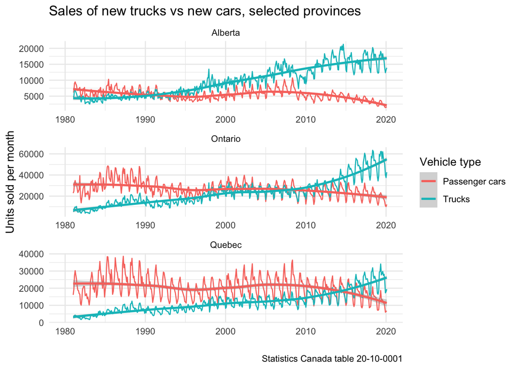

```r
mv_sales %>%
  normalize_cansim_values(factors=TRUE) %>%
  filter(`Vehicle type` %in% c("Trucks","Passenger cars"),
         `Origin of manufacture` == "Total, country of manufacture",
         Sales=="Units",
         GEO %in% c("Alberta","Quebec","Ontario"),
         `Seasonal adjustment`=="Unadjusted",
         Date >= "1980-01-01") %>%
  ggplot(., aes(x = Date, y = VALUE, colour = `Vehicle type`)) +
  geom_line() + geom_smooth() +
  facet_wrap(~GEO, scales = "free", ncol = 1) +
  theme_minimal() +
  labs(x = "", y = "Units sold per month",
      title="Sales of new trucks vs new cars, selected provinces",
      caption="Statistics Canada table 20-10-0001")
```

#### Ex. 2 - Bank of Canada yield curve

Power users of Statistics Canada data may already know the exact data vector they are looking for. The cansim package allows users to retrieve individual vector series as easily as full tables.

```r
yields <- get_cansim_vector(vectors = c("2YR"="v39051","10YR"="v39055"), start_time = "1992-01-01", end_time = "2020-05-25") %>%
  normalize_cansim_values() %>%
  select(Date, VALUE, label)
```

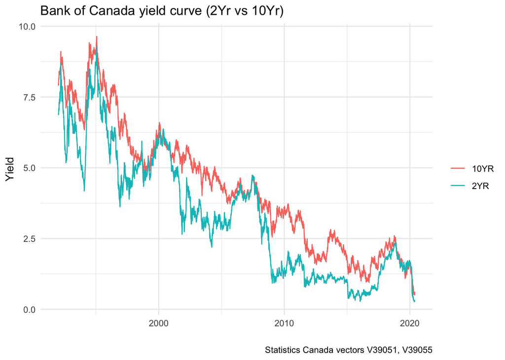

```r
yields %>%
  filter(VALUE != 0) %>%
  ggplot(. ,aes(x = Date, y = VALUE, colour = label)) +
  geom_line() +
  theme_minimal() +
  labs(x = "", y = "Yield",
      title="Bank of Canada yield curve (2Yr vs 10Yr)",
      caption="Statistics Canada vectors V39051, V39055",
      colour = "")
```

You can check out these fully reproducible examples with additional detail and context showing advanced use of the cansim package. Each post has a link to a github repo with fully reproducible code.

- [The fleecing of Canadian millenials](https://doodles.mountainmath.ca/blog/2019/01/31/the-fleecing-of-canadian-millenials/)
- [The cansim package, Canadian tourism, and slopegraphs](https://www.dshkol.com/2018/cansim-package-tourism-slopegraphs/)
- [Interprovincial migration](https://doodles.mountainmath.ca/blog/2018/06/14/interprovincial-migration/)